# Concrete_Strength_Prediction

### Problem Statement: Concrete Strength Prediction

#### Objective

To predict the concrete strength using the data available in file "concrete.csv". Apply feature engineering and model tuning to obtain 85% to 95% accuracy.

#### Resources Available

The data for this project is available in file https://archive.ics.uci.edu/ml/machine-learning-databases/concrete/compressive/. The same has been shared along with the course content.

#### Steps and Tasks:

##### Exploratory Data Quality Report Reflecting the Following:

1. Univariate analysis –data types and description of the independent attributes which should include (name, range of values observed, central values (mean and median), standard deviation and quartiles, analysis of the body of distributions/tails, missing values, outliers, duplicates **(10 Marks)**
2. Bi-variate analysis between the predictor variables and between the predictor variables and target column. Comment on your findings in terms of their relationship and degree of relation if any. Visualize the analysis using boxplots and pair plots, histograms, or density curves. **(10 marks)**
3. Feature Engineering techniques **(10 marks)** Identify opportunities (if any) to extract new features from existing features, drop a feature(if required) Get the data model ready and do a train test split. Decide on the complexity of the model, should it be a simple linear model in terms of parameters or would a quadratic or higher degree.

##### Creating the Model and Tuning It:

1. Algorithms that you think will be suitable for this project. Use Kfold Cross-Validation to evaluate model performance. Use appropriate metrics and make a DataFrame to compare models w.r.t their metrics. (at least 3 algorithms, one bagging and one boosting based algorithms have to be there). **(15 marks)**
2. Techniques employed to squeeze that extra performance out of the model without making it overfit. Use Grid Search or Random Search on any of the two models used above. Make a DataFrame to compare models after hyperparameter tuning and their metrics as above. **(15 marks)**

##### Attribute Information:

Given are the variable name, variable type, the measurement unit, and a brief description. The concrete compressive strength is the regression problem. The order of this listing corresponds to the order of numerals along the rows of the database.

##### Name Data Type Measurement Description

1. Cement (cement) quantitative kg in a m3 mixture Input Variable
2. Blast Furnace Slag (slag) quantitative kg in a m3 mixture Input Variable
3. Fly Ash (ash) quantitative kg in a m3 mixture Input Variable
4. Water(water) quantitative kg in a m3 mixture Input Variable
5. Superplasticizer (superplastic) quantitative kg in a m3 mixture Input Variable
6. Coarse Aggregate (coarseagg) quantitative kg in a m3 mixture Input Variable
7. Fine Aggregate (fineagg) quantitative kg in a m3 mixture Input Variable
8. Age(age) quantitative Day (1~365) Input Variable
9. Concrete compressive strength(strength) quantitative MPa Output Variable

```python
# GITHUB repository: https://github.com/yogesh-singal/PGP-AIML
```

### Exploratory data quality report

```python
import pandas as pd
import seaborn as sns
import matplotlib.pyplot as plt
import numpy as np
```

```python
data = pd.read_csv('concrete.csv');
```

```python
data.shape
```

```
(1030, 9)
```

```python
data.info()
```

```
<class 'pandas.core.frame.DataFrame'>
RangeIndex: 1030 entries, 0 to 1029
Data columns (total 9 columns):
 #   Column        Non-Null Count  Dtype
---  ------        --------------  -----
 0   cement        1030 non-null   float64
 1   slag          1030 non-null   float64
 2   ash           1030 non-null   float64
 3   water         1030 non-null   float64
 4   superplastic  1030 non-null   float64
 5   coarseagg     1030 non-null   float64
 6   fineagg       1030 non-null   float64
 7   age           1030 non-null   int64
 8   strength      1030 non-null   float64
dtypes: float64(8), int64(1)
memory usage: 72.5 KB
```

```python
data.isnull().sum()
```

```
cement          0
slag            0
ash             0
water           0
superplastic    0
coarseagg       0
fineagg         0
age             0
strength        0
dtype: int64
```

```python
data.isna().sum()
```

```
cement          0
slag            0
ash             0
water           0
superplastic    0
coarseagg       0
fineagg         0
age             0
strength        0
dtype: int64
```

**Insights**

- `There are no NULL values in the data`

```python
data.describe()
```

|  | cement | slag | ash | water | superplastic | coarseagg | fineagg | age | strength |
| --- | --- | --- | --- | --- | --- | --- | --- | --- | --- |
| count | 1030.000000 | 1030.000000 | 1030.000000 | 1030.000000 | 1030.000000 | 1030.000000 | 1030.000000 | 1030.000000 | 1030.000000 |
| mean | 281.167864 | 73.895825 | 54.188350 | 181.567282 | 6.204660 | 972.918932 | 773.580485 | 45.662136 | 35.817961 |
| std | 104.506364 | 86.279342 | 63.997004 | 21.354219 | 5.973841 | 77.753954 | 80.175980 | 63.169912 | 16.705742 |
| min | 102.000000 | 0.000000 | 0.000000 | 121.800000 | 0.000000 | 801.000000 | 594.000000 | 1.000000 | 2.330000 |
| 25% | 192.375000 | 0.000000 | 0.000000 | 164.900000 | 0.000000 | 932.000000 | 730.950000 | 7.000000 | 23.710000 |
| 50% | 272.900000 | 22.000000 | 0.000000 | 185.000000 | 6.400000 | 968.000000 | 779.500000 | 28.000000 | 34.445000 |
| 75% | 350.000000 | 142.950000 | 118.300000 | 192.000000 | 10.200000 | 1029.400000 | 824.000000 | 56.000000 | 46.135000 |
| max | 540.000000 | 359.400000 | 200.100000 | 247.000000 | 32.200000 | 1145.000000 | 992.600000 | 365.000000 | 82.600000 |

**Insights**

- `None of the columns have NULLs or negative values.`

#### 1. Univariate data analysis (10 marks)

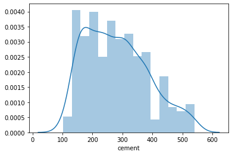

```python
sns.distplot(data.cement)
```

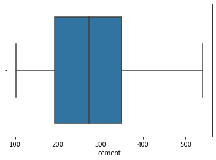

```python
sns.boxplot(data.cement)
```

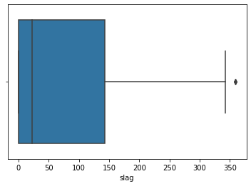

```python
sns.boxplot(data.slag)
```

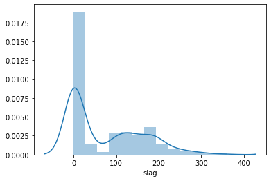

```python
sns.distplot(data.slag)
#, kde=False)
```

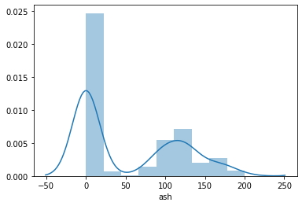

```python
sns.distplot(data.ash)
```

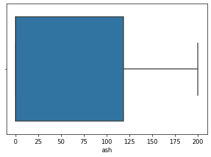

```python
sns.boxplot(data.ash)
```

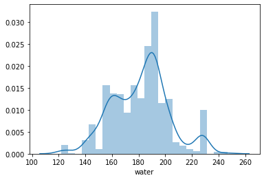

```python
sns.distplot(data.water)
```

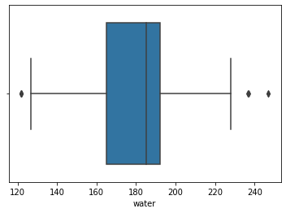

```python
sns.boxplot(data.water)
```

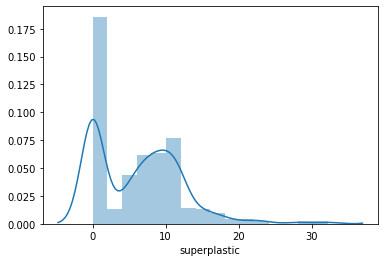

```python
sns.distplot(data.superplastic)
```

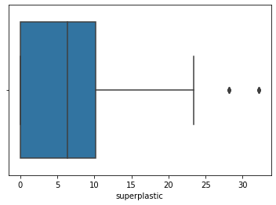

```python
sns.boxplot(data.superplastic)
```

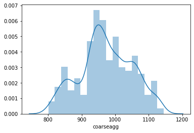

```python
sns.distplot(data.coarseagg)
```

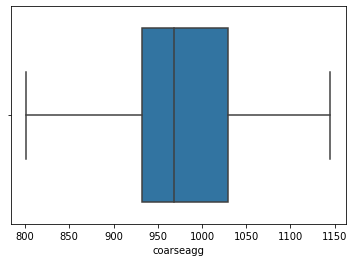

```python
sns.boxplot(data.coarseagg)
```

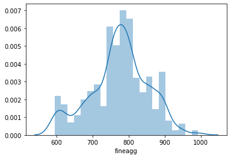

```python
sns.distplot(data.fineagg)
```

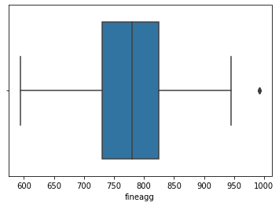

```python
sns.boxplot(data.fineagg)
```

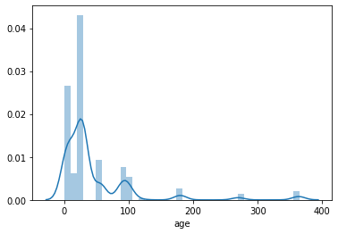

```python
sns.distplot(data.age)
```

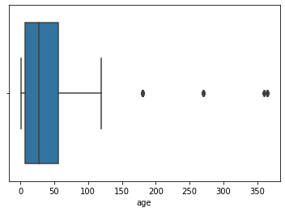

```python
sns.boxplot(data.age)
```

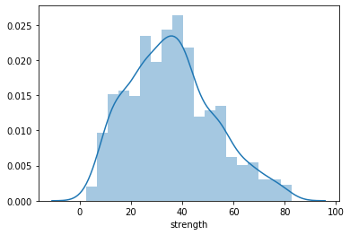

```python
sns.distplot(data.strength)
```

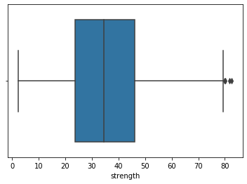

```python
sns.boxplot(data.strength)
```

```python
data.nunique()
```

```
cement          278
slag            185
ash             156
water           195
superplastic    111
coarseagg       284
fineagg         302
age              14
strength        845
dtype: int64
```

```python
duplicate = data[data.duplicated()]
print("Duplicate Rows :")

# Print the resultant Dataframe
duplicate
```

```
Duplicate Rows :
```

|  | cement | slag | ash | water | superplastic | coarseagg | fineagg | age | strength |
| --- | --- | --- | --- | --- | --- | --- | --- | --- | --- |
| 278 | 425.0 | 106.3 | 0.0 | 153.5 | 16.5 | 852.1 | 887.1 | 3 | 33.40 |
| 298 | 425.0 | 106.3 | 0.0 | 153.5 | 16.5 | 852.1 | 887.1 | 3 | 33.40 |
| 400 | 362.6 | 189.0 | 0.0 | 164.9 | 11.6 | 944.7 | 755.8 | 3 | 35.30 |
| 420 | 362.6 | 189.0 | 0.0 | 164.9 | 11.6 | 944.7 | 755.8 | 3 | 35.30 |
| 463 | 362.6 | 189.0 | 0.0 | 164.9 | 11.6 | 944.7 | 755.8 | 56 | 77.30 |
| 468 | 252.0 | 0.0 | 0.0 | 185.0 | 0.0 | 1111.0 | 784.0 | 28 | 19.69 |
| 482 | 425.0 | 106.3 | 0.0 | 153.5 | 16.5 | 852.1 | 887.1 | 91 | 65.20 |
| 493 | 362.6 | 189.0 | 0.0 | 164.9 | 11.6 | 944.7 | 755.8 | 91 | 79.30 |
| 517 | 425.0 | 106.3 | 0.0 | 153.5 | 16.5 | 852.1 | 887.1 | 56 | 64.30 |
| 525 | 362.6 | 189.0 | 0.0 | 164.9 | 11.6 | 944.7 | 755.8 | 28 | 71.30 |
| 527 | 425.0 | 106.3 | 0.0 | 153.5 | 16.5 | 852.1 | 887.1 | 91 | 65.20 |
| 576 | 362.6 | 189.0 | 0.0 | 164.9 | 11.6 | 944.7 | 755.8 | 7 | 55.90 |
| 577 | 425.0 | 106.3 | 0.0 | 153.5 | 16.5 | 852.1 | 887.1 | 28 | 60.29 |
| 604 | 362.6 | 189.0 | 0.0 | 164.9 | 11.6 | 944.7 | 755.8 | 56 | 77.30 |
| 733 | 362.6 | 189.0 | 0.0 | 164.9 | 11.6 | 944.7 | 755.8 | 91 | 79.30 |
| 738 | 362.6 | 189.0 | 0.0 | 164.9 | 11.6 | 944.7 | 755.8 | 28 | 71.30 |
| 766 | 362.6 | 189.0 | 0.0 | 164.9 | 11.6 | 944.7 | 755.8 | 91 | 79.30 |
| 830 | 425.0 | 106.3 | 0.0 | 153.5 | 16.5 | 852.1 | 887.1 | 7 | 49.20 |
| 880 | 425.0 | 106.3 | 0.0 | 153.5 | 16.5 | 852.1 | 887.1 | 56 | 64.30 |
| 884 | 425.0 | 106.3 | 0.0 | 153.5 | 16.5 | 852.1 | 887.1 | 7 | 49.20 |
| 892 | 362.6 | 189.0 | 0.0 | 164.9 | 11.6 | 944.7 | 755.8 | 56 | 77.30 |
| 933 | 362.6 | 189.0 | 0.0 | 164.9 | 11.6 | 944.7 | 755.8 | 7 | 55.90 |
| 943 | 362.6 | 189.0 | 0.0 | 164.9 | 11.6 | 944.7 | 755.8 | 3 | 35.30 |
| 967 | 362.6 | 189.0 | 0.0 | 164.9 | 11.6 | 944.7 | 755.8 | 28 | 71.30 |
| 992 | 425.0 | 106.3 | 0.0 | 153.5 | 16.5 | 852.1 | 887.1 | 28 | 60.29 |

```python
data.drop_duplicates(inplace = True)
```

```python
data.describe()
```

|  | cement | slag | ash | water | superplastic | coarseagg | fineagg | age | strength |
| --- | --- | --- | --- | --- | --- | --- | --- | --- | --- |
| count | 1005.000000 | 1005.000000 | 1005.000000 | 1005.000000 | 1005.000000 | 1005.000000 | 1005.000000 | 1005.000000 | 1005.000000 |
| mean | 278.631343 | 72.043483 | 55.536318 | 182.075323 | 6.033234 | 974.376816 | 772.688259 | 45.856716 | 35.250378 |
| std | 104.344261 | 86.170807 | 64.207969 | 21.339334 | 5.919967 | 77.579667 | 80.340435 | 63.734692 | 16.284815 |
| min | 102.000000 | 0.000000 | 0.000000 | 121.800000 | 0.000000 | 801.000000 | 594.000000 | 1.000000 | 2.330000 |
| 25% | 190.700000 | 0.000000 | 0.000000 | 166.600000 | 0.000000 | 932.000000 | 724.300000 | 7.000000 | 23.520000 |
| 50% | 265.000000 | 20.000000 | 0.000000 | 185.700000 | 6.100000 | 968.000000 | 780.000000 | 28.000000 | 33.800000 |
| 75% | 349.000000 | 142.500000 | 118.300000 | 192.900000 | 10.000000 | 1031.000000 | 822.200000 | 56.000000 | 44.870000 |
| max | 540.000000 | 359.400000 | 200.100000 | 247.000000 | 32.200000 | 1145.000000 | 992.600000 | 365.000000 | 82.600000 |

**Insights** 25 Duplicate rows were removed

#### 2. Bivariate data analysis (10 marks)

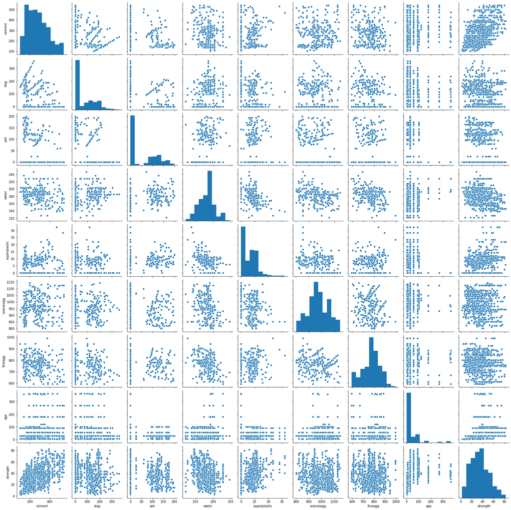

```python
sns.pairplot(data)
plt.show()
```

**Insights**

- There seems to be some sort of positive correlation between the amount of cement used and the strength of the concrete mixture
- Similarly with superplastic and strength, although it is not as pronounced

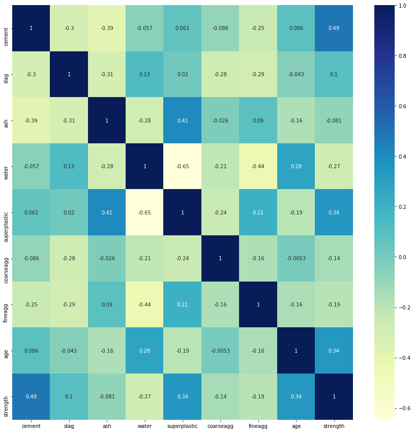

```python
plt.figure(figsize=(15,15))
sns.heatmap(data.corr(), annot = True, fmt='.2g',cmap= "YlGnBu")
```

**Insights**

- None of the variables are highly correlated with each other
- There seems to be some amount of positive correlation between the target variable strength and cement, age & superplastic

```python
# splitting data into training and test set for independent attributes
from sklearn.model_selection import train_test_split

X = data.drop(['strength'], axis=1)
Y = data['strength']   # Target variable

x_train, x_test, y_train, y_test = train_test_split(X, Y, test_size=0.3, random_state=1)
x_train.head()
```

|  | cement | slag | ash | water | superplastic | coarseagg | fineagg | age |
| --- | --- | --- | --- | --- | --- | --- | --- | --- |
| 443 | 190.3 | 0.0 | 125.2 | 166.6 | 9.9 | 1079.0 | 798.9 | 56 |
| 689 | 194.7 | 0.0 | 100.5 | 165.6 | 7.5 | 1006.4 | 905.9 | 56 |
| 1022 | 144.8 | 0.0 | 133.6 | 180.8 | 11.1 | 979.5 | 811.5 | 28 |
| 826 | 139.7 | 163.9 | 127.7 | 236.7 | 5.8 | 868.6 | 655.6 | 28 |
| 758 | 194.7 | 0.0 | 100.5 | 170.2 | 7.5 | 998.0 | 901.8 | 56 |

**Insights**

- Logistic Regression is not suitable because the target variable is not categorical. Try Linear Regression

**Feature Engineering techniques (10 marks)**

- Identify opportunities (if any) to extract new features from existing features, drop a feature(if required) Get the data model ready and do a train test split. Decide on the complexity of the model, should it be a simple linear model in terms of parameters or would a quadratic or higher degree.

```python
 from sklearn.linear_model import LinearRegression
reg = LinearRegression().fit(x_train, y_train)

print("Regression coefficients are:", reg.coef_, " and the intercept is :", reg.intercept_)

print("Training accuracy is:",reg.score(x_train,y_train))
print("Testing accuracy is:",reg.score(x_test, y_test))
```

```
Regression coefficients are: [ 0.13001791  0.1089221   0.09396745 -0.12028826  0.31834964  0.02308799
  0.03229064  0.10906711]  and the intercept is : -46.49337273611995
Training accuracy is: 0.6217217238825692
Testing accuracy is: 0.5419610271323054
```

**Insights**

- Both training and test accuracy scores of Linear Regression are low. Hence we need to try non-linear regression

```python
from sklearn.preprocessing import PolynomialFeatures
from sklearn import linear_model

poly = PolynomialFeatures(degree=3)
poly_variables = poly.fit_transform(X)

poly_var_train, poly_var_test, res_train, res_test = train_test_split(poly_variables, Y, test_size = 0.3, random_state = 4)

regression = linear_model.LinearRegression()
poly_model = regression.fit(poly_var_train, res_train)

column_names = poly.get_feature_names(X.columns)

print("Training R^2 is:", poly_model.score(poly_var_train, res_train))
print("Testing R^2 is:", poly_model.score(poly_var_test, res_test))
```

```
Training R^2 is: 0.9305499000160317
Testing R^2 is: 0.8562206371419857
```

```python
polyfeatures = pd.DataFrame({'Variable': column_names, 'Coeff': regression.coef_})
print(polyfeatures)
print("     ")
print('The Intercept is :% 0.3f' % regression.intercept_)
```

```
            Variable       Coeff
0                  1    0.008090
1             cement  -65.111324
2               slag  -54.736926
3                ash -366.049167
4              water -159.919923
..               ...         ...
160  coarseagg age^2    0.000003
161        fineagg^3   -0.000004
162    fineagg^2 age   -0.000005
163    fineagg age^2    0.000001
164            age^3    0.000004

[165 rows x 2 columns]

The Intercept is : 67424.896
```

**Insights**

- With 3rd degree polynomial regression, both training and test accuracy scores are greatly improved but the test score and train scores do not match. The model seems to be an overfit

**Creating the Model and Tuning It:**

- Algorithms that you think will be suitable for this project. Use Kfold Cross-Validation to evaluate model performance. Use appropriate metrics and make a DataFrame to compare models w.r.t their metrics. (at least 3 algorithms, one bagging and one boosting based algorithms have to be there). **(15 marks)**

```python
from sklearn.model_selection import KFold
from sklearn.model_selection import cross_val_score
from sklearn.pipeline import make_pipeline
from sklearn.preprocessing import StandardScaler
from sklearn.model_selection import LeaveOneOut
```

```python
#
# Create an instance of Pipeline
#
pipeline = make_pipeline(StandardScaler(), linear_model.LinearRegression())
kfold = KFold(n_splits=10, shuffle = True, random_state=77)
results = cross_val_score(pipeline, poly_var_train, res_train, cv=kfold)
print('Mean training R^2 and Std. deviation with 10 fold CV : %.3f (%.3f)' % (np.mean(abs(results)), np.std(results)))
print("Testing R^2 is:", poly_model.score(poly_var_test, res_test))
```

```
Mean training R^2 and Std. deviation with 10 fold CV : 0.738 (0.248)
Testing R^2 is: 0.8562206371419857
```

```python
results = cross_val_score(pipeline, poly_var_train, res_train, cv=LeaveOneOut())
print('Mean training R^2 and Std. deviation with 10 fold CV : %.3f (%.3f)' % (np.mean(results), np.std(results)))
```

[output not shown]

[output cut: 1349 more lines]

[output not shown]

```
Mean training R^2 and Std. deviation with 10 fold CV : nan (nan)
```

**Insights**

- Leave One out CV does not seem to work here
- Hence try with larger number of folds

```python
results = cross_val_score(pipeline, poly_var_train, res_train, cv=200)
print('Mean Training R^2 and Std deviation of results with 200 fold CV: %.3f (%.3f)' % (np.mean(abs(results)), np.std(results)))
regression.fit(poly_var_test, res_test)
print('Testing R^2: %0.3f ' % poly_model.score(poly_var_test, res_test))
```

```
Mean Training R^2 and Std deviation of results with 200 fold CV: 0.935 (1.432)
Testing R^2: 0.969
```

```python
model_performance_metrics = pd.DataFrame (columns = ['model','train_accuracy','test_accuracy'])
poly_metrics = {'model':"Polynomial Regression",'train_accuracy':np.mean(abs(results)),'test_accuracy':poly_model.score(poly_var_test, res_test)}
model_performance_metrics = model_performance_metrics.append(poly_metrics, ignore_index=True)
```

```python
from sklearn.tree import DecisionTreeRegressor
from sklearn import metrics

from sklearn.linear_model import LogisticRegression
from sklearn.model_selection import GridSearchCV, RandomizedSearchCV
from scipy.stats import uniform

dt_model = DecisionTreeRegressor()
dt_model.get_params()
```

```
{'ccp_alpha': 0.0,
 'criterion': 'mse',
 'max_depth': None,
 'max_features': None,
 'max_leaf_nodes': None,
 'min_impurity_decrease': 0.0,
 'min_impurity_split': None,
 'min_samples_leaf': 1,
 'min_samples_split': 2,
 'min_weight_fraction_leaf': 0.0,
 'presort': 'deprecated',
 'random_state': None,
 'splitter': 'best'}
```

```python
distributions = dict(max_depth=[10, 15, 20], min_samples_leaf=[2,4,6,10], max_features=[3,5,7,8], splitter=['random','best'])
clf = RandomizedSearchCV(dt_model, distributions, random_state=1)
search = clf.fit(x_train, y_train)
search.best_params_
```

```
{'splitter': 'best', 'min_samples_leaf': 4, 'max_features': 8, 'max_depth': 15}
```

```python
dt_model = DecisionTreeRegressor(max_depth = 15, min_samples_leaf=4, max_features=8, splitter = 'best',random_state=1)
dt_model.fit(x_train, y_train)
results = cross_val_score(dt_model, x_train, y_train, cv=30)
results
print('Mean R^2 and Std deviation of training results with 30 fold CV : %.3f (%.3f)' % (np.mean(abs(results)), np.std(results)))
```

```
Mean R^2 and Std deviation of training results with 30 fold CV : 0.804 (0.087)
```

```python
print (pd.DataFrame(dt_model.feature_importances_, columns = ["Imp"], index = x_train.columns))#Print the feature importance of the decision model
```

```
                   Imp
cement        0.367364
slag          0.063822
ash           0.022585
water         0.122226
superplastic  0.036458
coarseagg     0.021232
fineagg       0.038202
age           0.328110
```

```python
print('Testing R^2 is: %0.3f' % dt_model.score(x_test, y_test))
```

```
Testing R^2 is: 0.807
```

```python
dt_metrics = {'model':"Decision Tree",'train_accuracy':np.mean(abs(results)),'test_accuracy':dt_model.score(x_test, y_test)}

#append row to the dataframe
model_performance_metrics = model_performance_metrics.append(dt_metrics, ignore_index=True)
model_performance_metrics
```

|  | model | train_accuracy | test_accuracy |
| --- | --- | --- | --- |
| 0 | Polynomial Regression | 0.935434 | 0.969025 |
| 1 | Decision Tree | 0.804024 | 0.806792 |

```python
from sklearn.ensemble import GradientBoostingRegressor
from sklearn.model_selection import RepeatedKFold
from matplotlib import pyplot

gbr_model = GradientBoostingRegressor()
gbr_model.fit( x_train, y_train)
cv = RepeatedKFold(n_splits=200, n_repeats=3, random_state=1)
n_scores = cross_val_score(gbr_model,  x_train, y_train, cv=cv, n_jobs=-1, error_score='raise')
print('Mean training R^2 and std deviation with 200 fold CV : %.3f (%.3f)' % (np.mean(abs(n_scores)), np.std(n_scores)))

print('Testing R^2 : %.3f ' % gbr_model.score(x_test, y_test))
```

```
Mean training R^2 and std deviation with 200 fold CV : 0.901 (1.183)
Testing R^2 : 0.898
```

```python
gbr_metrics = {'model':"Gradient Boost",'train_accuracy':np.mean(abs(n_scores)),'test_accuracy':gbr_model.score(x_test, y_test)}

#append row to the dataframe
model_performance_metrics = model_performance_metrics.append(gbr_metrics, ignore_index=True)
model_performance_metrics
```

|  | model | train_accuracy | test_accuracy |
| --- | --- | --- | --- |
| 0 | Polynomial Regression | 0.935434 | 0.969025 |
| 1 | Decision Tree | 0.804024 | 0.806792 |
| 2 | Gradient Boost | 0.900656 | 0.897927 |

```python
from sklearn.ensemble import BaggingRegressor
from sklearn.datasets import make_regression

bg_regr = BaggingRegressor(base_estimator=dt_model,
                        n_estimators=10, random_state=0)
bg_regr.fit(x_train, y_train)
cv = RepeatedKFold(n_splits=20, n_repeats=3, random_state=1)
n_scores = cross_val_score(bg_regr,  x_train, y_train, cv=cv, n_jobs=-1, error_score='raise')
print('Mean training R^2 and std deviation with 20 fold CV: %.3f (%.3f)' % (np.mean(abs(n_scores)), np.std(n_scores)))
print('Testing R^2 : %.3f ' % bg_regr.score(x_test, y_test))
```

```
Mean training R^2 and std deviation with 20 fold CV: 0.860 (0.048)
Testing R^2 : 0.852
```

```python
bgr_metrics = {'model':"Bagging",'train_accuracy':np.mean(abs(n_scores)),'test_accuracy':bg_regr.score(x_test, y_test)}

#append row to the dataframe
model_performance_metrics = model_performance_metrics.append(bgr_metrics, ignore_index=True)
model_performance_metrics
```

|  | model | train_accuracy | test_accuracy |
| --- | --- | --- | --- |
| 0 | Polynomial Regression | 0.935434 | 0.969025 |
| 1 | Decision Tree | 0.804024 | 0.806792 |
| 2 | Gradient Boost | 0.900656 | 0.897927 |
| 3 | Bagging | 0.859857 | 0.851610 |

Techniques employed to squeeze that extra performance out of the model without making it overfit. Use Grid Search or Random Search on any of the two models used above. Make a DataFrame to compare models after hyperparameter tuning and their metrics as above. **(15 marks)**

**Insights**

```python
poly_model.get_params()
```

```
{'copy_X': True, 'fit_intercept': True, 'n_jobs': None, 'normalize': False}
```

```python
distributions = dict(normalize=[True, False])
clf = GridSearchCV(poly_model, distributions)
search = clf.fit(poly_var_train, res_train)
search.best_params_
```

```
{'normalize': False}
```

**Insights**

```python
gbr_model.get_params()
```

```
{'alpha': 0.9,
 'ccp_alpha': 0.0,
 'criterion': 'friedman_mse',
 'init': None,
 'learning_rate': 0.1,
 'loss': 'ls',
 'max_depth': 3,
 'max_features': None,
 'max_leaf_nodes': None,
 'min_impurity_decrease': 0.0,
 'min_impurity_split': None,
 'min_samples_leaf': 1,
 'min_samples_split': 2,
 'min_weight_fraction_leaf': 0.0,
 'n_estimators': 100,
 'n_iter_no_change': None,
 'presort': 'deprecated',
 'random_state': None,
 'subsample': 1.0,
 'tol': 0.0001,
 'validation_fraction': 0.1,
 'verbose': 0,
 'warm_start': False}
```

```python
distributions = dict(warm_start=[True, False], max_depth=[10, 15, 20], min_samples_leaf=[2,4,6,10], max_features=[3,5,7,8], validation_fraction=[0.05,0.1,0.2], learning_rate=[0.05,0.1,0.2, 0.3],alpha=[0.5,0.7,0.8,0.9],loss=['ls', 'lad', 'huber', 'quantile'], n_estimators=[50,100,200,500])
gbr = RandomizedSearchCV(gbr_model, distributions, random_state=1)
search = gbr.fit(x_train, y_train)
search.best_params_
```

```
{'warm_start': False,
 'validation_fraction': 0.2,
 'n_estimators': 200,
 'min_samples_leaf': 6,
 'max_features': 7,
 'max_depth': 20,
 'loss': 'lad',
 'learning_rate': 0.05,
 'alpha': 0.7}
```

```python
#
# Hence the final GradientBoosting model is as follows.
#
gbr_model = GradientBoostingRegressor(n_estimators=200,validation_fraction=0.2,min_samples_leaf=6,max_features=7,max_depth=20,loss='lad',learning_rate=0.05,alpha=0.7, random_state=1)
gbr_model.fit( x_train, y_train)
cv = RepeatedKFold(n_splits=20, n_repeats=3, random_state=1)
n_scores = cross_val_score(gbr_model,  x_train, y_train, cv=cv, n_jobs=-1, error_score='raise')
print('Mean training R^2 and std deviation with 200 fold CV : %.3f (%.3f)' % (np.mean(abs(n_scores)), np.std(n_scores)))

print('Testing R^2 : %.3f ' % gbr_model.score(x_test, y_test))
```

```
Mean training R^2 and std deviation with 200 fold CV : 0.913 (0.043)
Testing R^2 : 0.910
```

```python
model_performance_metrics.drop(index=[2], inplace=True)
gbr_metrics = {'model':"Gradient Boost",'train_accuracy':np.mean(abs(n_scores)),'test_accuracy':gbr_model.score(x_test, y_test)}

#append row to the dataframe
model_performance_metrics = model_performance_metrics.append(gbr_metrics, ignore_index=True)
model_performance_metrics
```

|  | model | train_accuracy | test_accuracy |
| --- | --- | --- | --- |
| 0 | Polynomial Regression | 0.935434 | 0.969025 |
| 1 | Decision Tree | 0.804024 | 0.806792 |
| 2 | Bagging | 0.859857 | 0.851610 |
| 3 | Gradient Boost | 0.912813 | 0.910192 |